# IFN509 Project

Wai Wing Chan (n9781463)

18 May 2018

## Task 1: Data Mining

Before starting any sub-tasks, the data set is imported and seed are set.

```r
#import the data set yeast.data.
yeast <- read.csv("C:/Users/User/Desktop/yeast.data", sep = "", header = F)

#name headers for yeast data set for easier manipulation
names(yeast) <- c("Sequence_Name", "mcg", "gvh", "alm", "mit", "erl", "pox", "vac", "nuc", "Localisation_Site")

#generate random numbers of 1234
set.seed(1234)
```

# Task 1(a)

Use a 70-30 split to create your training and test data.

```r
#create 2 sets of data sampled from yeast data set and assign 70% for training to train a model and 30% for test to evaluate the model
splitData <- sample(2, nrow(yeast), replace = T, prob = c(0.7, 0.3))
trainData <- yeast[splitData == 1,]
testData <- yeast[splitData == 2,]
```

# Task 1(b)

Use your training data to train a model

```r
#use party library
library(party)
#create a dataframe to specify the target variable (Localisation_Site) and all other independent variables (mcg, gvh, alm, mit, erl, pox, vac, nuc)
formula <- Localisation_Site ~mcg + gvh + alm + mit + erl + pox + vac + nuc

#use 'ctree' to build the decision tree model based on the formula configuration
yeast_ctree <- ctree(formula, data = trainData)
```

# Task 1(c)

Use your model to predict previously unseen data using the test data.

Test data is used for this task and a table containing predicted values (in rows) and true values (in columns) of the test data is presented.

```r
#create the table
table(predict(yeast_ctree, newdata = testData), testData$Localisation_Site)
```

```
##
##       CYT ERL EXC ME1 ME2 ME3 MIT NUC POX VAC
##   CYT  69   0   0   0   2   1  16  23   2   3
##   ERL   0   0   0   0   0   0   0   0   0   0
##   EXC   1   3   9   1   2   0   1   0   1   0
##   ME1   0   0   1   7   2   0   1   0   0   0
##   ME2   0   1   0   0   7   0   3   0   0   0
##   ME3   2   0   0   1   2  42   7   4   0   4
##   MIT  10   0   0   0   0   0  52  10   1   0
##   NUC  56   1   1   0   0   3   8  67   0   2
##   POX   0   0   0   0   0   0   0   0   3   0
##   VAC   0   0   0   0   0   0   0   0   0   0
```

# Task 1(d)

Produce a confusion matrix showing your predictions and report the accuracy of your model.

```r
#use caret library
library(caret)
#output the confusion matrix including evaluation measures like accuracy, sensitivity, specificity and so on
confusionMatrix(predict(yeast_ctree, newdata = testData), testData$Localisation_Site)
```

```
## Confusion Matrix and Statistics
##
##           Reference
## Prediction CYT ERL EXC ME1 ME2 ME3 MIT NUC POX VAC
##        CYT  69   0   0   0   2   1  16  23   2   3
##        ERL   0   0   0   0   0   0   0   0   0   0
##        EXC   1   3   9   1   2   0   1   0   1   0
##        ME1   0   0   1   7   2   0   1   0   0   0
##        ME2   0   1   0   0   7   0   3   0   0   0
##        ME3   2   0   0   1   2  42   7   4   0   4
##        MIT  10   0   0   0   0   0  52  10   1   0
##        NUC  56   1   1   0   0   3   8  67   0   2
##        POX   0   0   0   0   0   0   0   0   3   0
##        VAC   0   0   0   0   0   0   0   0   0   0
##
## Overall Statistics
##
##                Accuracy : 0.5926
##                  95% CI : (0.5446, 0.6393)
##     No Information Rate : 0.3194
##     P-Value [Acc > NIR] : < 2.2e-16
##
##                   Kappa : 0.481
##  Mcnemar's Test P-Value : NA
##
## Statistics by Class:
##
##                      Class: CYT Class: ERL Class: EXC Class: ME1
## Sensitivity              0.5000    0.00000    0.81818    0.77778
## Specificity              0.8401    1.00000    0.97862    0.99054
## Pos Pred Value           0.5948        NaN    0.50000    0.63636
## Neg Pred Value           0.7816    0.98843    0.99517    0.99525
## Prevalence               0.3194    0.01157    0.02546    0.02083
## Detection Rate           0.1597    0.00000    0.02083    0.01620
## Detection Prevalence     0.2685    0.00000    0.04167    0.02546
## Balanced Accuracy        0.6701    0.50000    0.89840    0.88416
##                      Class: ME2 Class: ME3 Class: MIT Class: NUC
## Sensitivity             0.46667    0.91304     0.5909     0.6442
## Specificity             0.99041    0.94819     0.9390     0.7835
## Pos Pred Value          0.63636    0.67742     0.7123     0.4855
## Neg Pred Value          0.98100    0.98919     0.8997     0.8741
## Prevalence              0.03472    0.10648     0.2037     0.2407
## Detection Rate          0.01620    0.09722     0.1204     0.1551
## Detection Prevalence    0.02546    0.14352     0.1690     0.3194
## Balanced Accuracy       0.72854    0.93062     0.7649     0.7139
##                      Class: POX Class: VAC
## Sensitivity            0.428571    0.00000
## Specificity            1.000000    1.00000
## Pos Pred Value         1.000000        NaN
## Neg Pred Value         0.990676    0.97917
## Prevalence             0.016204    0.02083
## Detection Rate         0.006944    0.00000
## Detection Prevalence   0.006944    0.00000
## Balanced Accuracy      0.714286    0.50000
```

As the confusion matrix shows, the accuracy of the model is 0.5926 (around 59.26%), which means out of 432 unseen observations (test data), this model accurately predicted 256 observations. The p-value is < 2.2e-16 which is much smaller than the conventional value of .05. The result is significant. On the other hand, the Kappa value compares the accuracy of the model to that of a random model (Markham, 2014), 0.481 Kappa means this model provides fairly good accuracy.

## Task 2: Visualization

# Task 2(a)

Produce a visualization of your classification model and how it makes decisions, when using a 70-30 split.

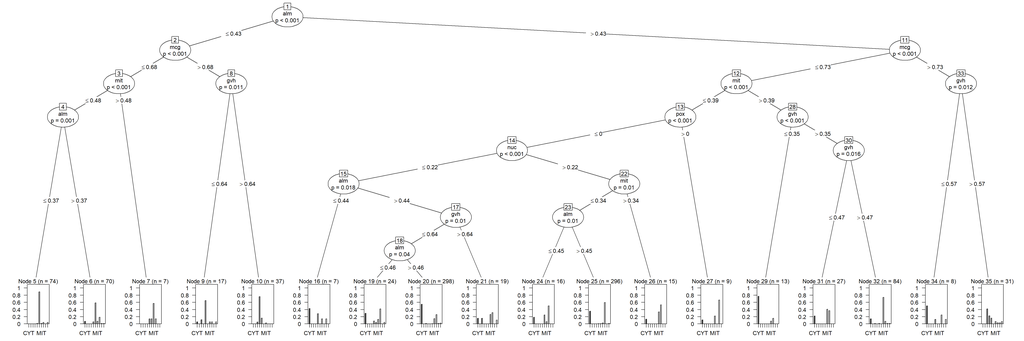

```r
#plot the decision tree out
plot(yeast_ctree)
```

alm <=0.43 has 4 nodes and 5 leaves whereas alm >0.43 has 12 nodes and 13 leaves.

The tree grows till reaching the target variable - the predicted class that informed by the independent variables - the reference classes/split criteria.

# Task 2(b)

Produce a visualization of your confusion matrix as a heatmap. Your heatmap should visualize the predicted variables and normalize these predictions between 0 and 1.

[figure not shown]

```r
library(ggplot2)

#make the decision tree data into data frame
heatmapData <- as.data.frame(table(predict(yeast_ctree, newdata = testData), testData$Localisation_Site))

#normalize data between 0-1 using Min-max normalisation
normalized = (heatmapData$Freq-min(heatmapData$Freq))/(max(heatmapData$Freq) - min(heatmapData$Freq))

#replace values of Freq with Normalised values
heatmapData[,"Freq"] <- normalized

#plot the heatmap out, x axis is the reference class, and y axis is the predicted class. It is filled based on normalized frequency between 0 to 1. The closer to 1, the deeper the color grid. rec
ggplot(heatmapData) + geom_tile(aes(x=Var1, y=Var2, fill=Freq), colors = "white") + scale_x_discrete(name = "Reference Class", position = "bottom") + scale_y_discrete (name = "Predicted Class") + scale_fill_gradient(breaks=seq(from=-.5, to=4, by=.25), low = "white", high = "midnightblue") + labs(title="Heatmap of The Yeast Classification Tree", fill="Normalized\nFrequency\n")
```

## Task 3: Data Analysis

# Task 3(a)

The confusion matrix shows that the classifier has 59.26% accuracy. It successfully predicted 256 cases (256 true positive) out of 432 data points, which also means that there are 40.74% false prediction - around 176 false positive.

In terms of effectiveness, high accuracy, that is getting the right outcome, brings high effectiveness. In this test, the classifier gives around 59% accuracy which is not that satisfactory in respect of effectiveness but the p-value gained is very small that indicates the model is significant. This classifier has room to improve but it can still be considered for this data set.

# Task 3(b)

• Provide a method to remove a few variables (at least two, more is better) from column 2 to column 9. You should provide a justification to answer why your solution is acceptable. (2 marks)

This method is adopted as below:

```r
#use caret library
library(caret)

#set cross validation control parameters (use repeated cross validation, 5 times of resmapling iteration, 3 complete sets of folds to compute)
control <- trainControl(method = "repeatedcv", number = 5, repeats = 3)

#build the train model of recursive partitioning ("rpart"), column "Sequence_Name" is excluded in this model.
model <- train(Localisation_Site~., data = yeast [, -which(names(yeast)=="Sequence_Name")], method = "rpart", preProcess = "scale")

#calculate and rank the importance of variables
importance <- varImp(model, scale = F)

#show the variable importance ranking list
importance
```

```
## rpart variable importance
##
##     Overall
## mit 124.890
## nuc 116.932
## alm 112.627
## mcg  87.538
## gvh  74.420
## pox  20.116
## vac   7.519
## erl   0.000
```

From the above ranking list, the variable with importance greater than 50 will be chosen for the new training mode, which are mit, nuc, alm, mcg, and gvh.

• Use a 70-30 split to create a new training model by using your selected independent variables and the target variable “localisation sites”. (2 marks)

```r
#create a cleaned yeast data set with erl, pox and vac excluded
yeast_Cleaned <- yeast[, -c(6:8)]

#generate random numbers of 1234
set.seed(1234)

#use 70-30 split for the new training model
splitData <- sample(2, nrow(yeast_Cleaned), replace = T, prob = c(0.7, 0.3))
trainData2 <- yeast_Cleaned[splitData == 1,]
testData2 <- yeast_Cleaned[splitData == 2,]
```

Now, create the new model.

```r
#only "mit", "nuc", "alm", "mcg" and "gvh" are included in the formula this time
formula2 <- Localisation_Site ~mit + nuc + alm + mcg + gvh

#use 'ctree' to build the decision tree model based on the above formula2
yeast_ctree2 <- ctree(formula2, data = trainData2)

#generate the confusion matrix and the statistics for this model
confusionMatrix(predict(yeast_ctree2, newdata = testData2), testData2$Localisation_Site)
```

```
## Confusion Matrix and Statistics
##
##           Reference
## Prediction CYT ERL EXC ME1 ME2 ME3 MIT NUC POX VAC
##        CYT  97   0   1   0   2   2  18  34   4   5
##        ERL   0   0   0   0   0   0   0   0   0   0
##        EXC   1   3   9   1   2   0   1   0   1   0
##        ME1   0   0   1   7   2   0   1   0   0   0
##        ME2   0   1   0   0   7   0   3   0   0   0
##        ME3   2   0   0   1   2  42   7   4   0   4
##        MIT  10   0   0   0   0   0  52  10   1   0
##        NUC  28   1   0   0   0   2   6  56   1   0
##        POX   0   0   0   0   0   0   0   0   0   0
##        VAC   0   0   0   0   0   0   0   0   0   0
##
## Overall Statistics
##
##                Accuracy : 0.625
##                  95% CI : (0.5775, 0.6708)
##     No Information Rate : 0.3194
##     P-Value [Acc > NIR] : < 2.2e-16
##
##                   Kappa : 0.5161
##  Mcnemar's Test P-Value : NA
##
## Statistics by Class:
##
##                      Class: CYT Class: ERL Class: EXC Class: ME1
## Sensitivity              0.7029    0.00000    0.81818    0.77778
## Specificity              0.7755    1.00000    0.97862    0.99054
## Pos Pred Value           0.5951        NaN    0.50000    0.63636
## Neg Pred Value           0.8476    0.98843    0.99517    0.99525
## Prevalence               0.3194    0.01157    0.02546    0.02083
## Detection Rate           0.2245    0.00000    0.02083    0.01620
## Detection Prevalence     0.3773    0.00000    0.04167    0.02546
## Balanced Accuracy        0.7392    0.50000    0.89840    0.88416
##                      Class: ME2 Class: ME3 Class: MIT Class: NUC
## Sensitivity             0.46667    0.91304     0.5909     0.5385
## Specificity             0.99041    0.94819     0.9390     0.8841
## Pos Pred Value          0.63636    0.67742     0.7123     0.5957
## Neg Pred Value          0.98100    0.98919     0.8997     0.8580
## Prevalence              0.03472    0.10648     0.2037     0.2407
## Detection Rate          0.01620    0.09722     0.1204     0.1296
## Detection Prevalence    0.02546    0.14352     0.1690     0.2176
## Balanced Accuracy       0.72854    0.93062     0.7649     0.7113
##                      Class: POX Class: VAC
## Sensitivity              0.0000    0.00000
## Specificity              1.0000    1.00000
## Pos Pred Value              NaN        NaN
## Neg Pred Value           0.9838    0.97917
## Prevalence               0.0162    0.02083
## Detection Rate           0.0000    0.00000
## Detection Prevalence     0.0000    0.00000
## Balanced Accuracy        0.5000    0.50000
```

• Discuss your experimental results (i.e., confusion matrix) against the results in Task 2 (b). (2 marks)

Recap the result in Task 2(b):

*As the confusion matrix shows, the accuracy of the model is 0.5926 (around 59.26%), which means out of 432 unseen observations (test data), this model accurately predicted 256 observations. The p-value is < 2.2e-16 which is much smaller than the conventional value of .05. The result is significant. On the other hand, the Kappa value compares the accuracy of the model to that of a random model (Markham, 2014), 0.481 Kappa means this model provides fairly good accuracy.*

The confusion matrix of the new model has a higher accuracy of 0.625 (around 62.5%) than the result in Task 2(b). 270 observations out of 432 unseen observations (testData2), which means 270 true positive, were accurately predicted using this new model. With respect to the p-value, it is the same as the previous test, which means this result is significant as well. The Kappa value of 0.5161 is a bit higher than that of the previous model (0.481), which means this model has slightly better accuracy. To summarize, it is believed that feature selection helped to improve the model performance.

# References:

https://machinelearningmastery.com/feature-selection-with-the-caret-r-package/

http://topepo.github.io/caret/train-models-by-tag.html

http://www.dataschool.io/simple-guide-to-confusion-matrix-terminology/

https://stats.stackexchange.com/questions/82162/cohens-kappa-in-plain-english